# Homework 1 | DATA 5600

## Data and Description

Energy can be produced from wind using windmills. Choosing a site for a wind farm (i.e. the location of the windmills), however, can be a multi-million dollar gamble. If wind is inadequate at the site, then the energy produced over the lifetime of the wind farm can be much less than the cost of building the operation. Hence, accurate prediction of wind speed at a candidate site can be an important component in the decision to build or not to build. Since energy produced varies as the square of the wind speed, even small errors in prediction can have serious consequences.

One possible solution to help predict wind speed at a candidate site is to use wind speed at a nearby reference site. A reference site is a nearby location where the wind speed is already being monitored and should, theoretically, be similar to the candidate site. Using information from the reference site will allow windmill companies to know the wind speed at the candidate site without going through a costly data collection period, if the reference site is a good predictor.

The Windmill data set contains measurements of wind speed (in meters per second m/s) at a **candidate site (CSpd) (column 1)** and at an accompanying **reference site (RSpd) (column 2)** for 1,116 areas. Download the Windmill.txt file from Canvas, and put it in the same folder as this Juptyer file.

#### 0. Replace the text "\< PUT YOUR NAME HERE >" with your full name. Load necessary libraries below.

```python
import pandas as pd
import numpy as np
from matplotlib import pyplot as plt
import statsmodels.api as sm
```

#### 1. Briefly explain why simple linear regression is an appropriate tool to use to address this business scenario.

Since the goal is to predict wind speed at a candidate site (CSpd) using wind speed at a reference site (RSpd), linear regression is ideal if there is a linear relationship between two continuous variables. If wind speeds at nearby locations are correlated, the model will fit a straight line that can be used to make predictions.

#### 2. Read in the data set, and call the dataframe "wind". Print the first few rows of the data. Print a summary of the data and make sure the data makes sense.

```python
df = pd.read_csv('Windmill.txt', sep=' ')
df.head()
```

|  | CSpd | RSpd |
| --- | --- | --- |
| 0 | 6.9 | 5.9666 |
| 1 | 7.1 | 7.2176 |
| 2 | 7.8 | 7.9405 |
| 3 | 6.9 | 6.0174 |
| 4 | 5.5 | 6.1646 |

#### 3. What is the outcome variable in this situation? (Think about which variable makes the most sense to be the response.)

`CSpd` is the outcome variable because that is what is unknown and we are trying to predict given`RSpd`.

#### 4. What is the explanatory variable in this situation?

`RSpd` is the explanatory variable.

#### 5. Create a scatterplot of the data with variables on the appropriate axes. *Make the plot square. Add descriptive axis labels with appropriate units.*

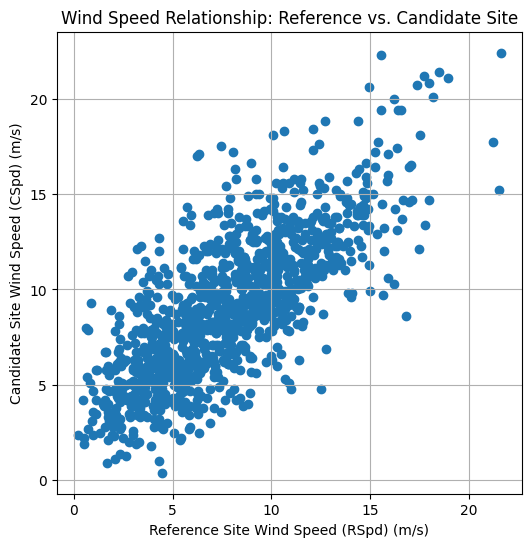

```python
plt.figure(figsize=(6, 6))
plt.scatter(df['RSpd'], df['CSpd'])

plt.xlabel('Reference Site Wind Speed (RSpd) (m/s)')
plt.ylabel('Candidate Site Wind Speed (CSpd) (m/s)')

plt.title("Wind Speed Relationship: Reference vs. Candidate Site")
plt.grid(True)
plt.show()
```

#### 6. Briefly describe the relationship between RSpd and CSpd. (Hint: you should refer to 3 main concepts in a complete sentence that includes referencing the variables.)

The scatterplot shows a positive correlation between the reference site wind speed (`RSpd`) and the candidate site wind speed (`CSpd`). As `RSpd` increases, `CSpd` also tends to increase, indicating a direct relationship. There appears to be some variance around the trend, suggesting that while there is a general linear relationship, other factors may also influence the wind speeds at the candidate site. The data points do not perfectly align, indicating that there are some prediction errors or deviations between the reference and candidate site wind speeds.

#### 7. Calculate the correlation coefficient for the two variables (you may use a built-in Python function). Print the result.

```python
correlation_coefficient = df['CSpd'].corr(df['RSpd'])
print("Pearson Correlation Coefficient:",correlation_coefficient)
```

```
Pearson Correlation Coefficient: 0.755594790599378
```

#### 8. Briefly interpret the number you calculated for the correlation coefficient (what is the direction and strength of the correlation?).

Like we observed in the scatter plot, there is a strong positive correlation. The coefficient, `0.756`, indicates this as it is positive and close to 1.

#### 9. Mathematically write out the *theoretical/general* simple linear regression model for this data set (using parameters ($\beta$'s), not estimates). Do not use "x" and "y" in your model - use variable names that are fairly descriptive.

$ \text{CSpd}_i = \beta_0 + \beta_1 \cdot \text{RSpd}_i + \epsilon_i $

Where:

- $\text{CSpd}_i$ = Wind speed at the candidate site for observation $i$ (dependent variable)
- $\text{RSpd}_i$ = Wind speed at the reference site for observation $i$ (independent variable)
- $\beta_0$ = The intercept
- $\beta_1$ = The slope
- $\epsilon_i$ = The error term for observation $i$

#### 10. (a) Apply linear regression to the data, and print out a summary of the results. (b) Save the residuals and fitted values to the `wind` dataframe, and print the first few rows of the `wind` dataframe.

```python
X = df['RSpd']
y = df['CSpd']

# Add a constant to the independent variable matrix (for the intercept)
X = sm.add_constant(X)

# Fit the linear regression model
model = sm.OLS(y, X).fit()

model.summary()
```

OLS Regression Results

| Dep. Variable: | CSpd | R-squared: | 0.571 |
| --- | --- | --- | --- |
| Model: | OLS | Adj. R-squared: | 0.571 |
| Method: | Least Squares | F-statistic: | 1482. |
| Date: | Tue, 10 Sep 2024 | Prob (F-statistic): | 6.63e-207 |
| Time: | 20:35:52 | Log-Likelihood: | -2589.9 |
| No. Observations: | 1116 | AIC: | 5184. |
| Df Residuals: | 1114 | BIC: | 5194. |
| Df Model: | 1 |  |  |
| Covariance Type: | nonrobust |  |  |

|  | coef | std err | t | P>\|t\| | [0.025 | 0.975] |
| --- | --- | --- | --- | --- | --- | --- |
| const | 3.1412 | 0.170 | 18.524 | 0.000 | 2.809 | 3.474 |
| RSpd | 0.7557 | 0.020 | 38.500 | 0.000 | 0.717 | 0.794 |

| Omnibus: | 35.417 | Durbin-Watson: | 1.415 |
| --- | --- | --- | --- |
| Prob(Omnibus): | 0.000 | Jarque-Bera (JB): | 40.806 |
| Skew: | 0.386 | Prob(JB): | 1.38e-09 |
| Kurtosis: | 3.531 | Cond. No. | 20.1 |

Notes:  
[1] Standard Errors assume that the covariance matrix of the errors is correctly specified.

```python
# Add the fitted values and residuals to the DataFrame
df['Fitted'] = model.fittedvalues
df['Residuals'] = model.resid

df.head()
```

|  | CSpd | RSpd | Fitted | Residuals |
| --- | --- | --- | --- | --- |
| 0 | 6.9 | 5.9666 | 7.650391 | -0.750391 |
| 1 | 7.1 | 7.2176 | 8.595813 | -1.495813 |
| 2 | 7.8 | 7.9405 | 9.142133 | -1.342133 |
| 3 | 6.9 | 6.0174 | 7.688782 | -0.788782 |
| 4 | 5.5 | 6.1646 | 7.800026 | -2.300026 |

#### 11. Add the OLS regression line to the scatterplot you created in 4. Print the result.

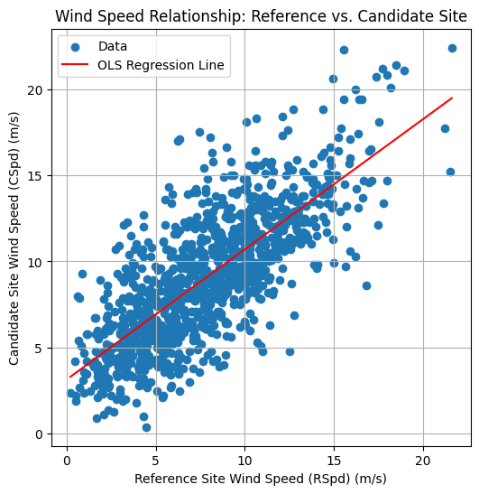

```python
plt.figure(figsize=(6, 6))
plt.scatter(df['RSpd'], df['CSpd'], label='Data')

# Calculate the regression line
# The model's coefficients
intercept = model.params['const']
slope = model.params['RSpd']
# Generate a range of values for the reference site wind speed
RSpd_range = pd.Series([df['RSpd'].min(), df['RSpd'].max()])
# Calculate the predicted wind speeds based on the regression line
CSpd_pred = intercept + slope * RSpd_range

# Plot the regression line
plt.plot(RSpd_range, CSpd_pred, color='red', label='OLS Regression Line')

# Labels and title
plt.xlabel('Reference Site Wind Speed (RSpd) (m/s)')
plt.ylabel('Candidate Site Wind Speed (CSpd) (m/s)')
plt.title("Wind Speed Relationship: Reference vs. Candidate Site")
plt.legend()
plt.grid(True)

# Show plot
plt.show()
```

#### 12. Briefly explain the rational behind the ordinary least-squares model fit (how does OLS choose the parameter estimates?).

Ordinary Least Squares (OLS) is a way to find the best-fitting line for data points. It does this by trying to minimize the gap between the actual data points and the line it draws. These gaps are the residuals, and they are the vertical distances between the data points and the line. OLS tries to make these gaps as small as possible by adjusting the line's slope and intercept. To account for positive and negative distances, it minimizes the squared distances. The result is a line that best represents the relationship between the variables.

#### 13. Mathematically write out the *fitted* simple linear regression model for this data set using the coefficients you found above (do not use parameters/$\beta$'s). Do not use "x" and "y" in your model - use variable names that are fairly descriptive.

$ \text{CSpd}_i = \text{3.1412} + ( \text{0.7557} \cdot \text{RSpd}_i ) + \epsilon_i $

#### 14. Interpret the coefficient for the slope.

As wind speed increases by $\text{1.0 m/s}$ at the reference site ($\text{RSpd}$), wind speed at the candidate site ($\text{CSpd}$) increases by $\text{0.7557 m/s}$.

#### 15. Interpret the coefficient for the intercept.

If the reference site has no wind ($\text{0 m/s}$), the candidate site is expected to have a wind speed of $\text{3.1412 m/s}$.

#### 16. What is the average wind speed at the candidate site (CSpd) when the wind speed at the reference site (RSpd) is 12 m/s? Show your code, and print the result.

```python
# Intercept and slope variables were created in step 11
print("CSpd when RSpd is 12 m/s:",intercept + (slope *12))
```

```
CSpd when RSpd is 12 m/s: 12.210032281993497
```

#### 17. Briefly explain why it would be wrong to answer this question: What is the average wind speed at the candidate site (CSpd) when the wind speed at the reference site (RSpd) is 25 m/s?

```python
max_rspd = df['RSpd'].max()
max_rspd
```

```
np.float64(21.6015)
```

This would be extrapolation. Since our highest x-value (RSpd) is 21.6, making predictions for values beyond this range (such as 25 m/s) can lead to inaccurate or misleading predictions. The model is only valid within the range of the data used to create it, and predicting beyond this range assumes that the relationship between the candidate and reference sites remains the same (which may not be true).

#### 18. Calculate the estimate of $\sigma^2$, the average squared variability of the residuals around the line. This is called the Mean Squared Error (MSE). Show your code, and print the result.

```python
# Residual Sum of Squares (RSS)
RSS = sum(model.resid**2)

# Number of observations
n = len(df)

# Estimate of sigma squared
sigma_squared = RSS / (n - 2)
sigma_squared
```

```
6.0823116425499375
```

#### 19. Briefly summarize what you learned from this analysis *to a non-statistician*. Write a few sentences about (1) the purpose of this data set and analysis and (2) what you learned about this data set from your analysis. Write your response as if you were addressing a business manager (avoid using statistics jargon) and just provide the main take-aways.

The purpose of this analysis was to understand whether we can use wind speeds from a reference site to predict wind speeds at a nearby candidate site, which is important when deciding where to place wind farms. By building a model based on the data, we found that there is a clear relationship: when wind speed increases at the reference site, it also tends to increase at the candidate site, but not at a one-to-one rate. This means the reference site is useful for predicting wind speeds, though our model also showed some variability, so predictions won’t be perfect. Overall, the analysis suggests the reference site can help guide decisions but with some uncertainty.